# Evidencia 1 | Análisis Inicial

Karina Ruiz Tron

2022-04-25

## Primer avance

### Parte 1

**1. Investiga, ¿Cuál es la situación actual de COVID-19 a nivel mundial, en México, en tu estado de origen y en tu municipio, alcaldía o colonia?** Nivel mundial: de acuerdo a los datos recopilados por la página statista, a nivel mundial hay alrededor de 492,094,044 casos confirmados de COVID-19 al día 17 de abril del 2022. En México: de acuerdo a los datos recopilados por la página statista, en México hay 5,731,635 casos confirmados de COVID-19 al día 22 de abril del 2022. Ciudad de México: de acuerdo a los datos recopilados por la página Johns Hopkins, en la ciudad del México se han detectado 11,658 casos de coronavirus en los últimos 28 días. En mi alcaldía (Coyoacán): de acuerdo a los datos recopilados por la página del gobierno de México dedicada al COVID-19, en la alcaldía de Coyoacán hay 77,222 casos confirmados al día 14 de abril del 2022.

**2. ¿Cuál fue la primera variante del virus que se propagó a todo el mundo?** La beta fue descubierta primero (Mayo 2020), sin embargo, la variante alfa (Septiembre 2020) fue la que se esparció a nivel mundial más rápido, fue declarada como una variante preocupante o de interés el 18 de diciembre junto con la beta.

**3. ¿Cuáles son las otras variantes del virus que existen en otras regiones del mundo?** Las variantes Delta y Omicron se encuentran actualmente activas alrededor del mundo.

**4. ¿Cómo buscarías información de la variante del virus en tu país?** Buscaría información en la página del gobierno de mi país (Gobierno de México) debido a que emiten informes semanales de variantes COVID-19. Además ingresaría a la página de la Organización Mundial de la Salud (OMS) para poder aprender sobre la variante en general.

**5. Imagina que te encuentras en una situación similar a la de Li Wenliang, médico chino que intentó alertar sobre el brote de coronavirus en su país, pero fue detenido por las autoridades y obligado a retractarse, ¿qué harías en su caso? Selecciona un inciso:a) Lo reportas al centro de investigación o la universidad. b) Lo reportas a la prensa. c) Guardas la información.** Yo escogería reportarlo a la prensa para evitar que este virus pudiera extenderse y concientizar a las personas sobre los riesgos de contraer esta enfermedad. Sin embargo, viviría con el constante miedo de que las autoridades pudieran hacerle algo a mi familia por no haberlos obedecido.

### Parte 2

*Variante Alpha*

```r
#install.packages("seqinr")
library("seqinr")

alpha <- read.fasta("/Users/karinaruiztron/Downloads/Programas de programacion/R/Evidencia1_bio/sarscov2alpha.fasta")
class(alpha)
```

```
## [1] "list"
```

```r
str(alpha)
```

```
## List of 1
##  $ LC654481.1: 'SeqFastadna' chr [1:29848] "a" "t" "t" "a" ...
##   ..- attr(*, "name")= chr "LC654481.1"
##   ..- attr(*, "Annot")= chr ">LC654481.1 Severe acute respiratory syndrome coronavirus 2 KKH094 genomic RNA, complete genome"
```

```r
#Tamaño de la secuencia
length(alpha[[1]])
```

```
## [1] 29848
```

```r
#Composición de nucleótidos
c<-count(alpha[[1]], 1)
est.x=(c)
print(est.x)
```

```
##
##    a    c    g    t
## 8917 5476 5852 9603
```

```r
table(alpha[[1]])
```

```
##
##    a    c    g    t
## 8917 5476 5852 9603
```

```r
#Contenido de GC en cada virus
alpha_fasta<-porcentaje(alpha[[1]])
```

```
## [1] "El porcentaje de 'G' es: "
## [1] 19.606
## [1] "El porcentaje de 'C' es: "
## [1] 18.34629
```

```r
#Secuencia contrasentido
 contra<- function(dna){
  dna1<-length(dna)
  inv<-dna[dna1:1]
  return(inv)
  }
contra(alpha[[1]])
```

[output not shown]

[output cut: 42 more lines]

*Variante Beta*

```r
#install.packages("seqinr")
library("seqinr")

beta <- read.fasta("/Users/karinaruiztron/Downloads/Programas de programacion/R/Evidencia1_bio/sarscov2beta.fasta")
class(beta)
```

```
## [1] "list"
```

```r
str(beta)
```

```
## List of 1
##  $ ON322586.1: 'SeqFastadna' chr [1:29767] "t" "t" "g" "t" ...
##   ..- attr(*, "name")= chr "ON322586.1"
##   ..- attr(*, "Annot")= chr ">ON322586.1 Severe acute respiratory syndrome coronavirus 2 isolate SARS-CoV-2/human/SouthAfrica/NHLS-UCT-GS-72"| __truncated__
```

```r
#Tamaño de la secuencia
length(beta[[1]])
```

```
## [1] 29767
```

```r
#Composición de nucleótidos
c<-count(beta[[1]], 1)
est.k=(c)
print(est.k)
```

```
##
##    a    c    g    t
## 8888 5457 5842 9580
```

```r
table(beta[[1]])
```

```
##
##    a    c    g    t
## 8888 5457 5842 9580
```

```r
#Contenido de GC en cada virus
beta_fasta<-porcentaje(beta[[1]])
```

```
## [1] "El porcentaje de 'G' es: "
## [1] 19.62576
## [1] "El porcentaje de 'C' es: "
## [1] 18.33238
```

```r
#Secuencia contrasentido
 contra<- function(dna){
  dna1<-length(dna)
  inv<-dna[dna1:1]
  return(inv)
  }
contra(beta[[1]])
```

[output not shown]

[output cut: 42 more lines]

*Variante Delta*

```r
#install.packages("seqinr")
library("seqinr")

delta <- read.fasta("/Users/karinaruiztron/Downloads/Programas de programacion/R/Evidencia1_bio/sarscov2delta.fasta")
class(delta)
```

```
## [1] "list"
```

```r
str(delta)
```

```
## List of 1
##  $ ON316696.1: 'SeqFastadna' chr [1:29861] "a" "a" "c" "c" ...
##   ..- attr(*, "name")= chr "ON316696.1"
##   ..- attr(*, "Annot")= chr ">ON316696.1 Severe acute respiratory syndrome coronavirus 2 isolate SARS-CoV-2/human/USA/CA-SDCPHL-051821-070/2"| __truncated__
```

```r
#Tamaño de la secuencia
length(delta[[1]])
```

```
## [1] 29861
```

```r
#Composición de nucleótidos
c<-count(delta[[1]], 1)
est.i=(c)
print(est.i)
```

```
##
##    a    c    g    t
## 8940 5470 5852 9599
```

```r
table(delta[[1]])
```

```
##
##    a    c    g    t
## 8940 5470 5852 9599
```

```r
#Contenido de GC en cada virus
delta_fasta<-porcentaje(delta[[1]])
```

```
## [1] "El porcentaje de 'G' es: "
## [1] 19.59747
## [1] "El porcentaje de 'C' es: "
## [1] 18.31821
```

```r
#Secuencia contrasentido
 contra<- function(dna){
  dna1<-length(dna)
  inv<-dna[dna1:1]
  return(inv)
  }
contra(delta[[1]])
```

[output not shown]

[output cut: 42 more lines]

*Variante Gamma*

```r
#install.packages("seqinr")
library("seqinr")

gamma <- read.fasta("/Users/karinaruiztron/Downloads/Programas de programacion/R/Evidencia1_bio/sarscov2gamma.fasta")
class(gamma)
```

```
## [1] "list"
```

```r
str(gamma)
```

```
## List of 1
##  $ ON316567.1: 'SeqFastadna' chr [1:29844] "a" "g" "a" "t" ...
##   ..- attr(*, "name")= chr "ON316567.1"
##   ..- attr(*, "Annot")= chr ">ON316567.1 Severe acute respiratory syndrome coronavirus 2 isolate SARS-CoV-2/human/USA/CA-SDCPHL-042721-280/2"| __truncated__
```

```r
#Tamaño de la secuencia
length(gamma[[1]])
```

```
## [1] 29844
```

```r
#Composición de nucleótidos
c<-count(gamma[[1]], 1)
est.l=(c)
print(est.l)
```

```
##
##    a    c    g    t
## 8939 5470 5850 9584
```

```r
table(gamma[[1]])
```

```
##
##    a    c    g    m    t
## 8939 5470 5850    1 9584
```

```r
#Contenido de GC en cada virus
gamma_fasta<-porcentaje(gamma[[1]])
```

```
## [1] "El porcentaje de 'G' es: "
## [1] 19.60193
## [1] "El porcentaje de 'C' es: "
## [1] 18.32864
```

```r
#Secuencia contrasentido
 contra<- function(dna){
  dna1<-length(dna)
  inv<-dna[dna1:1]
  return(inv)
  }
contra(gamma[[1]])
```

[output not shown]

[output cut: 42 more lines]

*Variante Omicron*

```r
#install.packages("seqinr")
library("seqinr")

omicron <- read.fasta("/Users/karinaruiztron/Downloads/Programas de programacion/R/Evidencia1_bio/sarscov2omicron.fasta")
class(omicron)
```

```
## [1] "list"
```

```r
str(omicron)
```

```
## List of 1
##  $ ON188698.1: 'SeqFastadna' chr [1:29730] "t" "a" "g" "a" ...
##   ..- attr(*, "name")= chr "ON188698.1"
##   ..- attr(*, "Annot")= chr ">ON188698.1 Severe acute respiratory syndrome coronavirus 2 isolate SARS-CoV-2/human/USA/UT-UPHL-220331228012/2"| __truncated__
```

```r
#Tamaño de la secuencia
length(omicron[[1]])
```

```
## [1] 29730
```

```r
#Composición de nucleótidos
c<-count(omicron[[1]], 1)
est.v=(c)
print(est.v)
```

```
##
##    a    c    g    t
## 8883 5442 5831 9574
```

```r
table(omicron[[1]])
```

```
##
##    a    c    g    t
## 8883 5442 5831 9574
```

```r
#Contenido de GC en cada virus
omicron_fasta<-porcentaje(omicron[[1]])
```

```
## [1] "El porcentaje de 'G' es: "
## [1] 19.61319
## [1] "El porcentaje de 'C' es: "
## [1] 18.30474
```

```r
#Secuencia contrasentido
 contra<- function(dna){
  dna1<-length(dna)
  inv<-dna[dna1:1]
  return(inv)
  }
contra(omicron[[1]])
```

[output not shown]

[output cut: 42 more lines]

*Función Porcentaje*

```r
porcentaje <- function(dna){
  g1 <- 0
  c1 <- 0

  l <- length(dna)

  for (i in 1:l){
    if (dna[i] == "g"){
      g1 <- g1+1
    }
    else if (dna[i] == "c"){
      c1 <- c1+1
    }
  }

  pg <- g1/l*100
  pc <- c1/l*100


  print("El porcentaje de 'G' es: ")
  print(pg)

  print("El porcentaje de 'C' es: ")
  print(pc)
}

n <- strsplit(dna,split = "")[[1]]


porcentaje(n)
```

```
## [1] "El porcentaje de 'G' es: "
## [1] 0
## [1] "El porcentaje de 'C' es: "
## [1] 100
```

```r
  # create a dataset
ca<-count(alpha[[1]], 1)
est.x=(ca)
print(est.x)
```

```
##
##    a    c    g    t
## 8917 5476 5852 9603
```

```r
cb<-count(beta[[1]], 1)
est.k=(cb)
print(est.k)
```

```
##
##    a    c    g    t
## 8888 5457 5842 9580
```

```r
cg<-count(delta[[1]], 1)
est.i=(cg)
print(est.i)
```

```
##
##    a    c    g    t
## 8940 5470 5852 9599
```

```r
cd<-count(gamma[[1]], 1)
est.l=(cd)
print(est.l)
```

```
##
##    a    c    g    t
## 8939 5470 5850 9584
```

```r
co<-count(omicron[[1]], 1)
est.v=(co)
print(est.v)
```

```
##
##    a    c    g    t
## 8883 5442 5831 9574
```

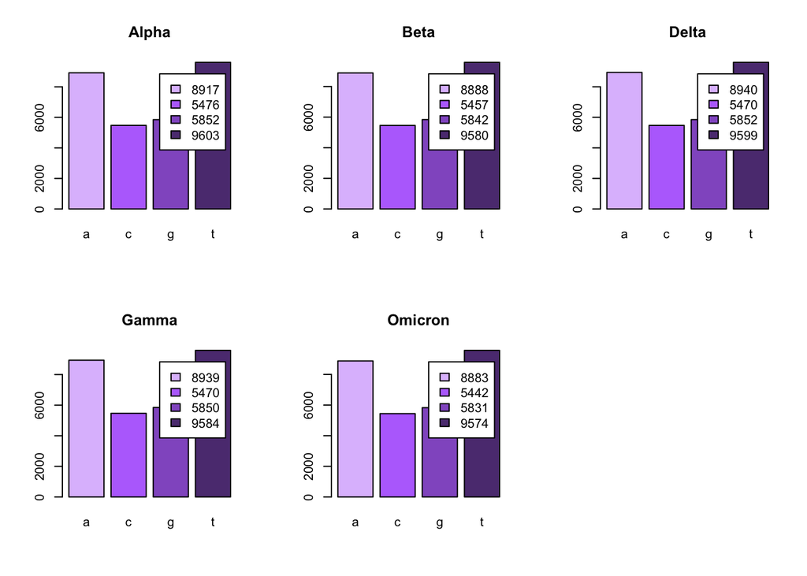

```r
par(mfrow = c(2, 3))

barplot(ca, beside=TRUE, legend=as.factor(unique(est.x)), col = c("#DFC0FD", "#B874FC", "#935DC9","#5D3B80"), main="Alpha")
barplot(cb, beside=TRUE, legend=as.factor(unique(est.k)), col = c("#DFC0FD", "#B874FC", "#935DC9","#5D3B80"), main="Beta")
barplot(cg, beside=TRUE, legend=as.factor(unique(est.i)), col = c("#DFC0FD", "#B874FC", "#935DC9","#5D3B80"), main="Delta")
barplot(cd, beside=TRUE, legend=as.factor(unique(est.l)), col = c("#DFC0FD", "#B874FC", "#935DC9","#5D3B80"), main="Gamma")
barplot(co, beside=TRUE, legend=as.factor(unique(est.v)), col = c("#DFC0FD", "#B874FC", "#935DC9","#5D3B80"), main="Omicron")
```

**Interpretación de las gráficas** En primera instancia se puede observar que las cinco gráficas tienen varios elementos en común como son la longitud de la hebra además de la cantidad de adenina y timina que estas poseen. Esto puede deberse al hecho de que todas son variantes del mismo virus (SARS-CoV-2). Además de esas priemras observaciones no existe otro elemento que, a mí parecer, sea indispensable de mencionar en esta interpretación.

### Referencias

Gobierno de México. (2022, 24 abril). COVID-19 Tablero CDMX. Geoint COVID - 19 Tablero CDMX. https://cdmx.dash.covid19.geoint.mx/

Johns Hopkins Coronavirus Resource Center. (s. f.). COVID-19 Map. https://coronavirus.jhu.edu/map.html

Linde, P. (2021, 2 diciembre). De la alfa a la ómicron: cómo las variantes del coronavirus se impusieron o se quedaron por el camino. El País. https://elpais.com/sociedad/2021-12-02/de-la-alfa-a-la-omicron-como-las-variantes-del-coronavirus-se-impusieron-o-se-quedaron-por-el-camino.html

Statista. (2022, 21 abril). COVID-19: casos confirmados a nivel mundial por continente en 2022. https://es.statista.com/estadisticas/1107712/covid19-casos-confirmados-a-nivel-mundial-por-region/

Statista. (2022b, abril 22). COVID-19: países afectados según los casos confirmados de contagio en 2022. https://es.statista.com/estadisticas/1091192/paises-afectados-por-el-coronavirus-de-wuhan-segun-los-casos-confirmados/